# Analysis of Sustainable Development Goals

SOfia

## Introduction

This analysis focuses on the first three Sustainable Development Goals (SDGs) SDG1(Ending Poverty),SDG2(Zero Hunger),SDG3(Good Health and Well-being in Kenya,Ghana,EGypt,Botswana and Cameroon.

## Data Import

```r
# Load necessary libraries
library(tidyverse)
library(table1)
# Load the dataset
gdp_data <- read.csv("Final.csv")

# Preview the dataset
head(gdp_data)
```

```
##    Country Code year GDPphead MaternalMortRate NeonatalDeathRate stuntPerc5
## 1 Botswana  BWA 2000 10629.95              262              16.6       29.1
## 2 Botswana  BWA 2001 10457.15              271              17.0       29.0
## 3 Botswana  BWA 2002 10896.88              278              17.8       29.0
## 4 Botswana  BWA 2003 11205.40              278              18.7       29.0
## 5 Botswana  BWA 2004 11305.57              264              19.6       29.0
## 6 Botswana  BWA 2005 11600.33              239              20.4       29.0
##   PrcntBelowPovertyLine NoPeopleBPovertyLine unfedprcnt
## 1              41.41439               389792       21.8
## 2              41.41439               389792       23.7
## 3              49.56479               496721       24.1
## 4              41.41439               389792       24.5
## 5              41.41439               389792       23.7
## 6              41.41439               389792       22.6
```

```r
#View(gdp_data)
```

## Data Cleaning

I extracted the data from a set of datasets spanning the years 2000 to 2017 for the specified countries. Due to the presence of many missing values, i replaced them with the mean value of the corresponding variables for each country. In total, there were 90 observations and 10 variables.

```r
# Display cleaned dataset summary
summary(gdp_data)
```

```
##    Country              Code                year         GDPphead
##  Length:90          Length:90          Min.   :2000   Min.   : 2807
##  Class :character   Class :character   1st Qu.:2004   1st Qu.: 3254
##  Mode  :character   Mode  :character   Median :2008   Median : 4111
##                                        Mean   :2008   Mean   : 6648
##                                        3rd Qu.:2013   3rd Qu.:10331
##                                        Max.   :2017   Max.   :16042
##  MaternalMortRate NeonatalDeathRate   stuntPerc5    PrcntBelowPovertyLine
##  Min.   : 37.0    Min.   :11.50     Min.   :17.50   Min.   :13.19
##  1st Qu.:165.5    1st Qu.:21.15     1st Qu.:25.15   1st Qu.:41.41
##  Median :340.5    Median :24.65     Median :29.00   Median :53.74
##  Mean   :355.2    Mean   :25.03     Mean   :29.39   Mean   :46.85
##  3rd Qu.:551.8    3rd Qu.:30.48     3rd Qu.:34.15   3rd Qu.:56.99
##  Max.   :886.0    Max.   :35.80     Max.   :40.80   Max.   :70.17
##  NoPeopleBPovertyLine   unfedprcnt
##  Min.   :  327147     Min.   : 3.80
##  1st Qu.: 1578845     1st Qu.: 6.10
##  Median : 5266028     Median :12.60
##  Mean   : 5740706     Mean   :14.55
##  3rd Qu.: 7723223     3rd Qu.:21.88
##  Max.   :14059525     Max.   :34.90
```

```r
str(gdp_data)
```

```
## 'data.frame':    90 obs. of  10 variables:
##  $ Country              : chr  "Botswana" "Botswana" "Botswana" "Botswana" ...
##  $ Code                 : chr  "BWA" "BWA" "BWA" "BWA" ...
##  $ year                 : int  2000 2001 2002 2003 2004 2005 2006 2007 2008 2009 ...
##  $ GDPphead             : num  10630 10457 10897 11205 11306 ...
##  $ MaternalMortRate     : int  262 271 278 278 264 239 221 209 203 189 ...
##  $ NeonatalDeathRate    : num  16.6 17 17.8 18.7 19.6 20.4 21 21.6 22 22.4 ...
##  $ stuntPerc5           : num  29.1 29 29 29 29 29 29 28.9 29 29 ...
##  $ PrcntBelowPovertyLine: num  41.4 41.4 49.6 41.4 41.4 ...
##  $ NoPeopleBPovertyLine : int  389792 389792 496721 389792 389792 389792 389792 389792 389792 345509 ...
##  $ unfedprcnt           : num  21.8 23.7 24.1 24.5 23.7 22.6 22.3 22.2 22 21.9 ...
```

##factor of categorical variables

```r
gdp_data$Code<-factor(gdp_data$Code)
gdp_data$year<-factor(gdp_data$year)
str(gdp_data)
```

```
## 'data.frame':    90 obs. of  10 variables:
##  $ Country              : chr  "Botswana" "Botswana" "Botswana" "Botswana" ...
##  $ Code                 : Factor w/ 5 levels "BWA","CMR","EGY",..: 1 1 1 1 1 1 1 1 1 1 ...
##  $ year                 : Factor w/ 18 levels "2000","2001",..: 1 2 3 4 5 6 7 8 9 10 ...
##  $ GDPphead             : num  10630 10457 10897 11205 11306 ...
##  $ MaternalMortRate     : int  262 271 278 278 264 239 221 209 203 189 ...
##  $ NeonatalDeathRate    : num  16.6 17 17.8 18.7 19.6 20.4 21 21.6 22 22.4 ...
##  $ stuntPerc5           : num  29.1 29 29 29 29 29 29 28.9 29 29 ...
##  $ PrcntBelowPovertyLine: num  41.4 41.4 49.6 41.4 41.4 ...
##  $ NoPeopleBPovertyLine : int  389792 389792 496721 389792 389792 389792 389792 389792 389792 345509 ...
##  $ unfedprcnt           : num  21.8 23.7 24.1 24.5 23.7 22.6 22.3 22.2 22 21.9 ...
```

```r
View(gdp_data)
```

```r
#data$Year<-factor(data$Year)
gdp_data$GDPphead<-as.numeric(gdp_data$GDPphead)
gdp_data$NeonatalDeathRate<-as.numeric(gdp_data$NeonatalDeathRate)
gdp_data$NoPeopleBPovertyLine<-as.integer(gdp_data$NoPeopleBPovertyLine)
gdp_data$unfedprcnt<-as.numeric(gdp_data$unfedprcnt)
gdp_data$stuntPerc5<-as.numeric(gdp_data$stuntPerc5)
gdp_data$stuntPerc5 <- round(gdp_data$stuntPerc5, 2)
gdp_data$GDPphead <- round(gdp_data$GDPphead, 2)
gdp_data$NeonatalDeathRate <- round(gdp_data$NeonatalDeathRate, 2)
gdp_data$unfedprcnt <- round(gdp_data$unfedprcnt, 2)
```

```r
#clean_data <- na.omit(gdp_data)
# Preview cleaned data
str(gdp_data)
```

```
## 'data.frame':    90 obs. of  10 variables:
##  $ Country              : chr  "Botswana" "Botswana" "Botswana" "Botswana" ...
##  $ Code                 : Factor w/ 5 levels "BWA","CMR","EGY",..: 1 1 1 1 1 1 1 1 1 1 ...
##  $ year                 : Factor w/ 18 levels "2000","2001",..: 1 2 3 4 5 6 7 8 9 10 ...
##  $ GDPphead             : num  10630 10457 10897 11205 11306 ...
##  $ MaternalMortRate     : int  262 271 278 278 264 239 221 209 203 189 ...
##  $ NeonatalDeathRate    : num  16.6 17 17.8 18.7 19.6 20.4 21 21.6 22 22.4 ...
##  $ stuntPerc5           : num  29.1 29 29 29 29 29 29 28.9 29 29 ...
##  $ PrcntBelowPovertyLine: num  41.4 41.4 49.6 41.4 41.4 ...
##  $ NoPeopleBPovertyLine : int  389792 389792 496721 389792 389792 389792 389792 389792 389792 345509 ...
##  $ unfedprcnt           : num  21.8 23.7 24.1 24.5 23.7 22.6 22.3 22.2 22 21.9 ...
```

## Descriptive Statistics

Summarize maternal mortality and GDP per capita across regions and countries.

```r
# Summary statistics for maternal mortality and GDP
attach(gdp_data)
tab2<- table1(~ GDPphead+MaternalMortRate|Code , data=gdp_data)
tab2
```

|  | BWA (N=18) | CMR (N=18) | EGY (N=18) | GHA (N=18) | KEN (N=18) | Overall (N=90) |
| --- | --- | --- | --- | --- | --- | --- |
| GDPphead |  |  |  |  |  |  |
| Mean (SD) | 13100 (1920) | 3240 (233) | 9440 (1160) | 3810 (816) | 3610 (358) | 6650 (4130) |
| Median [Min, Max] | 13100 [10500, 16000] | 3220 [2860, 3670] | 9900 [7740, 11000] | 3600 [2810, 5120] | 3550 [3150, 4200] | 4110 [2810, 16000] |
| MaternalMortRate |  |  |  |  |  |  |
| Mean (SD) | 206 (47.8) | 654 (110) | 47.7 (8.77) | 361 (47.6) | 507 (141) | 355 (231) |
| Median [Min, Max] | 196 [144, 278] | 612 [529, 886] | 45.0 [37.0, 64.0] | 341 [308, 484] | 493 [342, 708] | 341 [37.0, 886] |

## Exploratory Data Analysis

Visualize the relationship between maternal mortality and GDP per capita, and examine distributions.

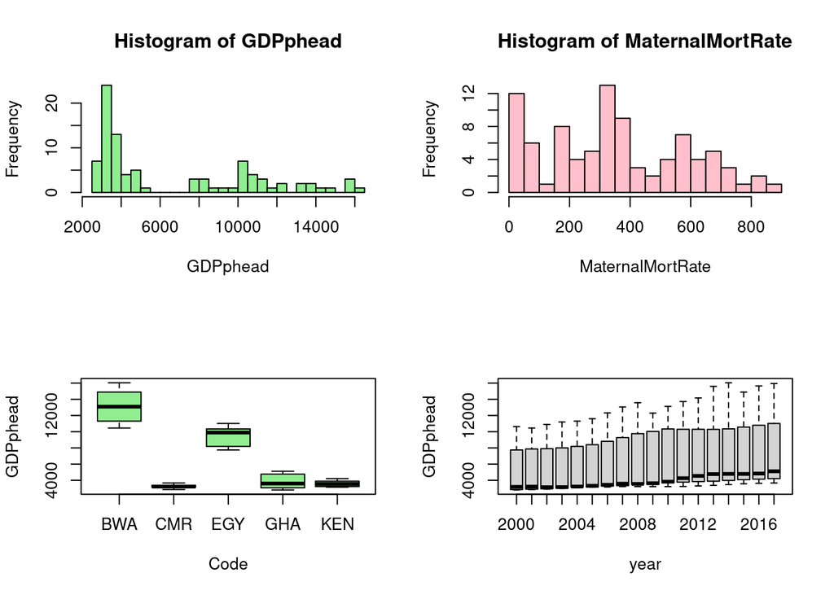

```r
 par(mfrow=c(2,2))
 hist(GDPphead,col="lightgreen",breaks = 20)
 hist(MaternalMortRate,col="pink",breaks=20)
 boxplot(GDPphead~Code,col="lightgreen")
 boxplot(GDPphead~year)
```

## Modeling: Maternal Mortality and GDP per Capita

```r
# Fit the linear model
model1 <- glm(MaternalMortRate ~ GDPphead, data = gdp_data,family = "poisson")

# Display model summary
summary(model1)
```

```
##
## Call:
## glm(formula = MaternalMortRate ~ GDPphead, family = "poisson",
##     data = gdp_data)
##
## Deviance Residuals:
##      Min        1Q    Median        3Q       Max
## -14.0813   -6.8814   -0.0904    7.4339   13.1998
##
## Coefficients:
##               Estimate Std. Error z value Pr(>|z|)
## (Intercept)  6.773e+00  1.092e-02  620.08   <2e-16 ***
## GDPphead    -1.627e-04  2.008e-06  -81.03   <2e-16 ***
## ---
## Signif. codes:  0 '***' 0.001 '**' 0.01 '*' 0.05 '.' 0.1 ' ' 1
##
## (Dispersion parameter for poisson family taken to be 1)
##
##     Null deviance: 14869.3  on 89  degrees of freedom
## Residual deviance:  5907.3  on 88  degrees of freedom
## AIC: 6575.4
##
## Number of Fisher Scoring iterations: 5
```

## plots of the model

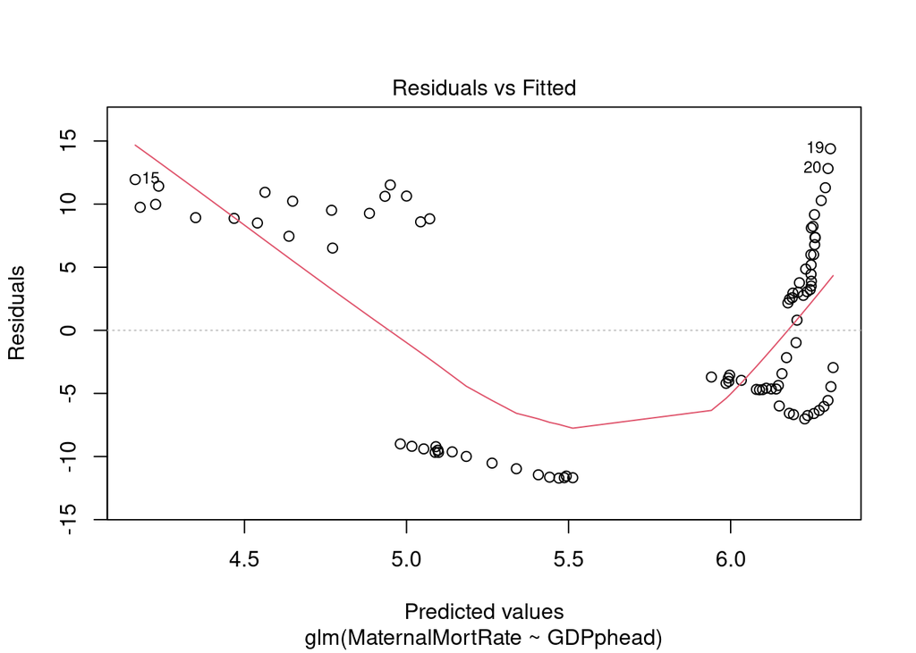

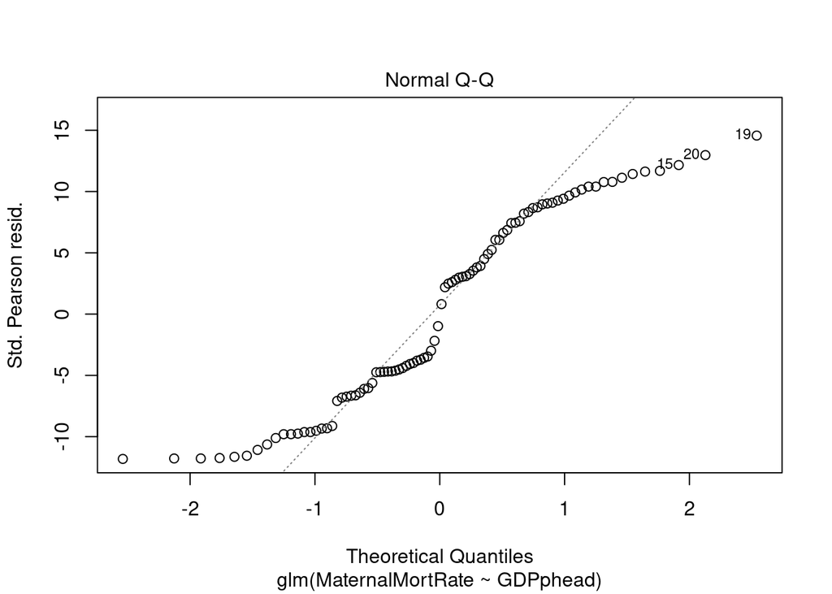

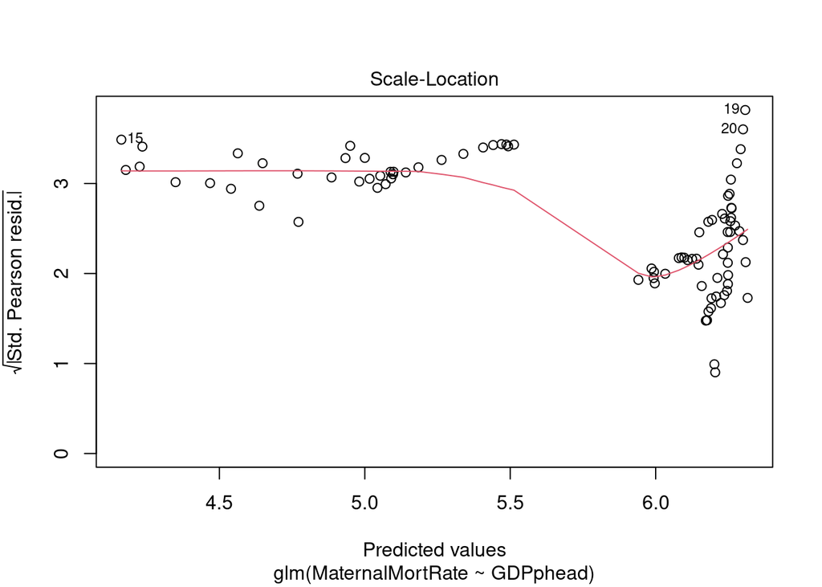

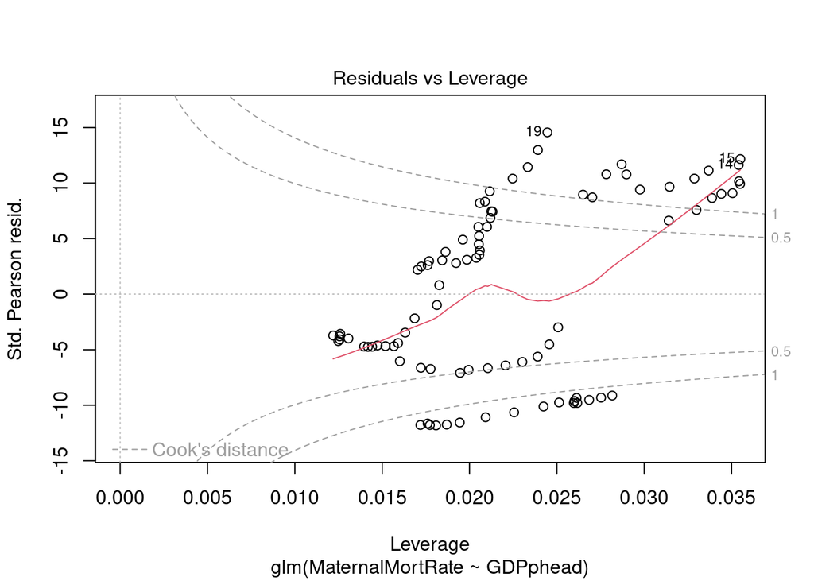

```r
plot(model1)
```

## Exploratory data Analysis

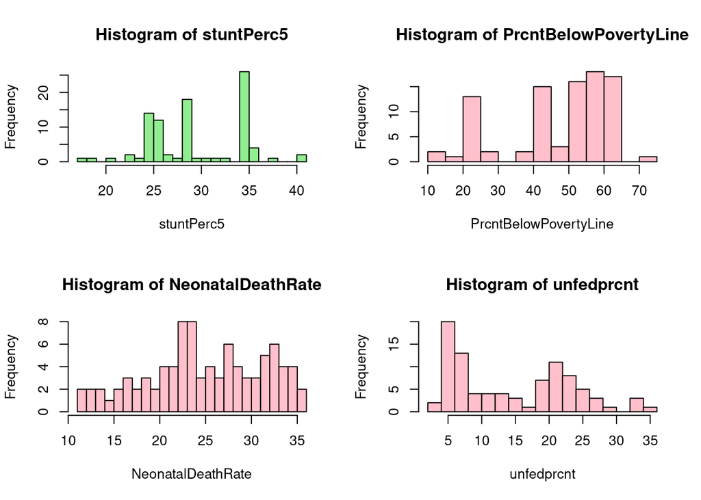

```r
 par(mfrow=c(2,2))
 hist(stuntPerc5,col="lightgreen",breaks = 20)
 hist(PrcntBelowPovertyLine,col="pink",breaks=20)
 hist(NeonatalDeathRate,col="pink",breaks=20)
 hist(unfedprcnt,col="pink",breaks=20)
```

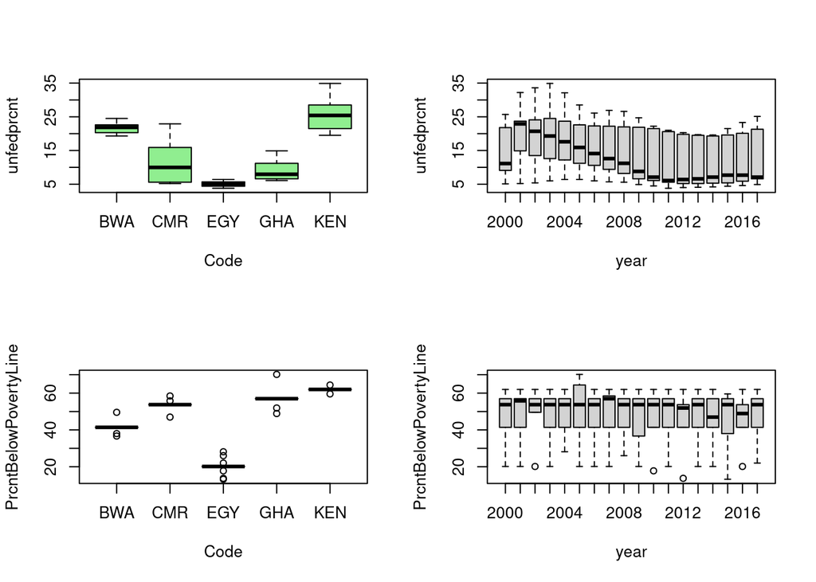

```r
 par(mfrow=c(2,2))
 boxplot(unfedprcnt~Code,col="lightgreen")
 boxplot(unfedprcnt~year)
 boxplot(PrcntBelowPovertyLine~Code,col="lightgreen")
 boxplot(PrcntBelowPovertyLine~year)
```

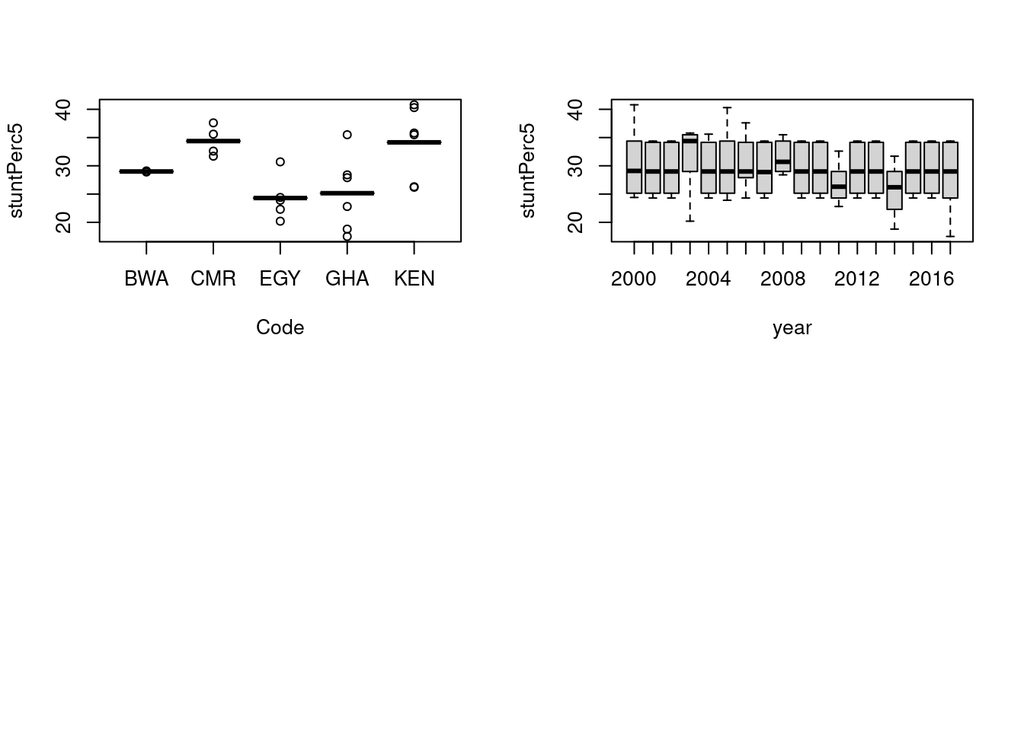

```r
 par(mfrow=c(2,2))
 boxplot(stuntPerc5~Code,col="lightgreen")
 boxplot(stuntPerc5~year)
```

## Summary Table

```r
tab3<- table1(~ stuntPerc5+PrcntBelowPovertyLine+unfedprcnt+NeonatalDeathRate|Code , data=gdp_data)
tab3
```

|  | BWA (N=18) | CMR (N=18) | EGY (N=18) | GHA (N=18) | KEN (N=18) | Overall (N=90) |
| --- | --- | --- | --- | --- | --- | --- |
| stuntPerc5 |  |  |  |  |  |  |
| Mean (SD) | 29.0 (0.0343) | 34.4 (1.14) | 24.3 (1.91) | 25.2 (3.68) | 34.2 (3.53) | 29.4 (4.94) |
| Median [Min, Max] | 29.0 [28.9, 29.1] | 34.4 [31.7, 37.6] | 24.3 [20.2, 30.7] | 25.2 [17.5, 35.5] | 34.2 [26.2, 40.8] | 29.0 [17.5, 40.8] |
| PrcntBelowPovertyLine |  |  |  |  |  |  |
| Mean (SD) | 41.4 (2.43) | 53.7 (2.06) | 20.1 (3.41) | 57.0 (3.95) | 62.0 (0.828) | 46.9 (15.3) |
| Median [Min, Max] | 41.4 [36.7, 49.6] | 53.7 [47.0, 58.5] | 20.1 [13.2, 28.1] | 57.0 [48.9, 70.2] | 62.0 [59.6, 64.4] | 53.7 [13.2, 70.2] |
| unfedprcnt |  |  |  |  |  |  |
| Mean (SD) | 21.8 (1.58) | 11.1 (5.99) | 5.07 (0.825) | 9.06 (2.79) | 25.7 (4.93) | 14.5 (8.71) |
| Median [Min, Max] | 21.9 [19.3, 24.5] | 9.97 [5.20, 22.9] | 5.00 [3.80, 6.40] | 7.95 [6.10, 14.9] | 25.4 [19.5, 34.9] | 12.6 [3.80, 34.9] |
| NeonatalDeathRate |  |  |  |  |  |  |
| Mean (SD) | 21.2 (2.31) | 32.0 (2.12) | 16.6 (3.57) | 30.4 (3.40) | 25.1 (2.14) | 25.0 (6.35) |
| Median [Min, Max] | 22.2 [16.6, 23.3] | 32.2 [28.0, 35.6] | 16.4 [11.5, 22.4] | 30.9 [24.7, 35.8] | 24.9 [21.8, 28.2] | 24.7 [11.5, 35.8] |

## Second model

```r
model2<-lm(NeonatalDeathRate~stuntPerc5+PrcntBelowPovertyLine+unfedprcnt,data = gdp_data)
summary(model2)
```

```
##
## Call:
## lm(formula = NeonatalDeathRate ~ stuntPerc5 + PrcntBelowPovertyLine +
##     unfedprcnt, data = gdp_data)
##
## Residuals:
##     Min      1Q  Median      3Q     Max
## -6.7825 -2.9886  0.1293  2.1070  7.9561
##
## Coefficients:
##                       Estimate Std. Error t value Pr(>|t|)
## (Intercept)            5.59435    2.49500   2.242   0.0275 *
## stuntPerc5             0.26378    0.10380   2.541   0.0128 *
## PrcntBelowPovertyLine  0.34592    0.03173  10.902  < 2e-16 ***
## unfedprcnt            -0.31089    0.05597  -5.554 3.06e-07 ***
## ---
## Signif. codes:  0 '***' 0.001 '**' 0.01 '*' 0.05 '.' 0.1 ' ' 1
##
## Residual standard error: 3.709 on 86 degrees of freedom
## Multiple R-squared:  0.6705, Adjusted R-squared:  0.659
## F-statistic: 58.33 on 3 and 86 DF,  p-value: < 2.2e-16
```

## model evaluation

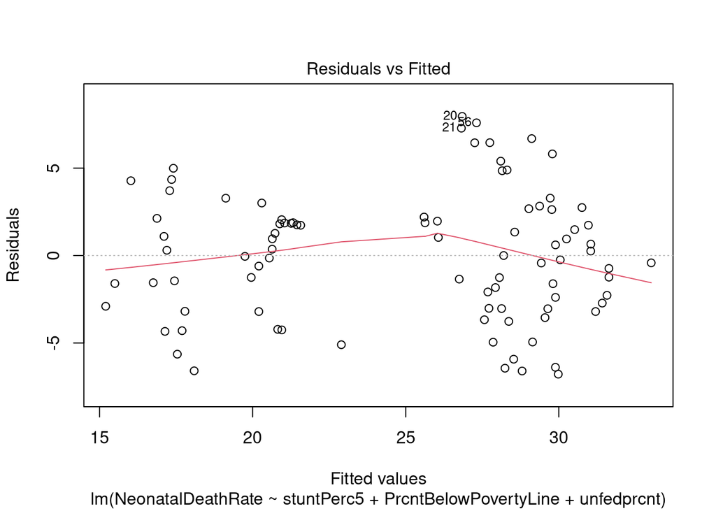

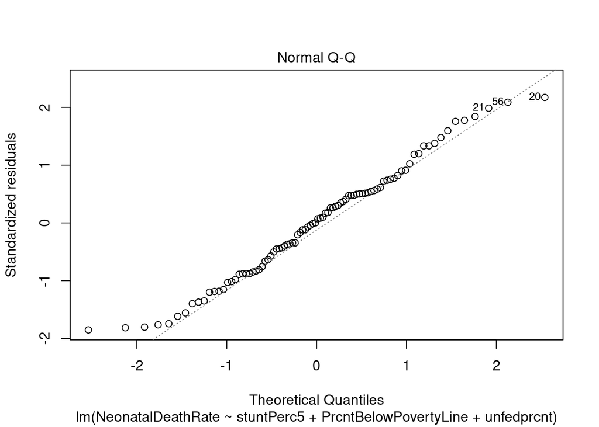

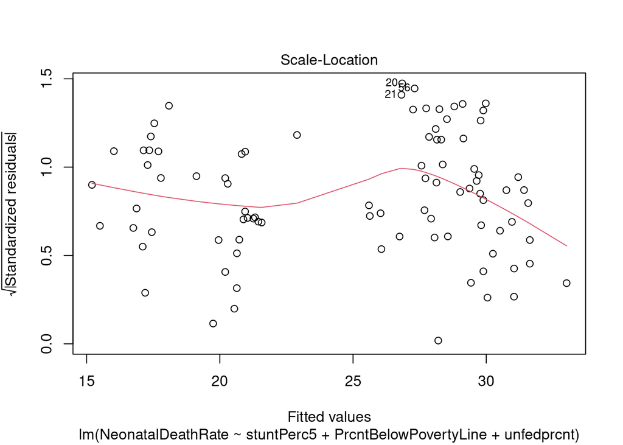

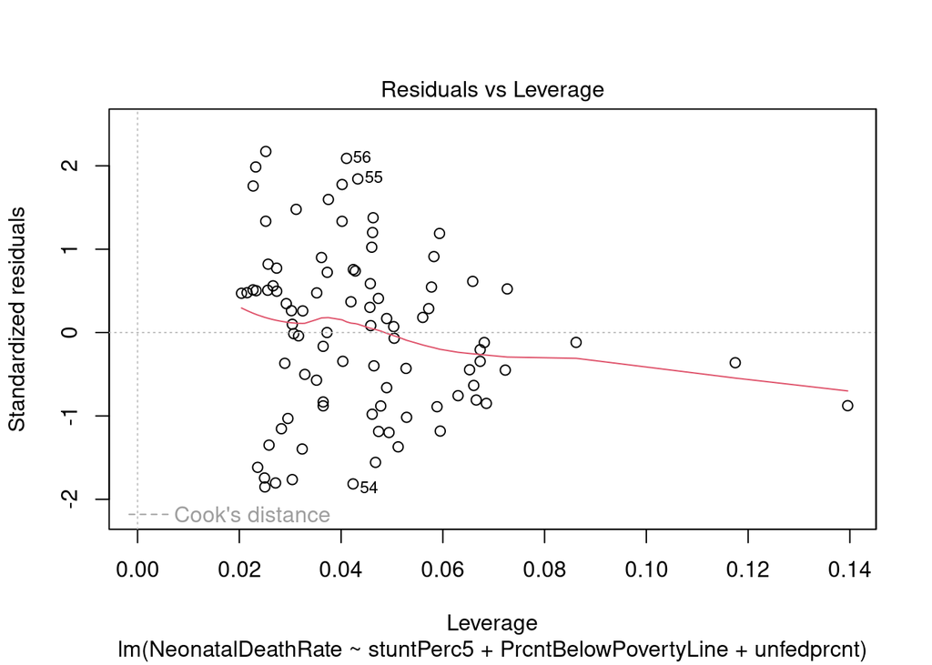

```r
plot(model2)
```